# EMBL-EBI Cancer genomics and transcriptomics course: Mutational signatures analysis

Francesc Muyas, PhD

11/07/2023

# Mutational signatures analysis: refitting with known signatures

During this practical session, we will focus on the detection and interpretation of mutational signatures in real samples. Particularly, you’ll with perform the refitting mutational signature analysis.

The process of signature refitting involves measuring the impact of a specific set of signatures on the mutational profile of a sample. This is particularly valuable when analyzing mutational signatures in small groups or individual samples, as well as for comparing one’s own findings with established signatures and published research.

The data used in this section is publicly available WES data generated from Ji et at. 2020. The somatic variant calling was performed using Strelka2.

For that, we will work with this R package: [*MutationalPatterns*](https://bioconductor.org/packages/release/bioc/html/MutationalPatterns.html).

### Preparing and loading the data

### Required packages

```r
#---
# Loading required packages
#---
suppressWarnings(library(data.table))
suppressWarnings(library(BSgenome))
ref_genome <- "BSgenome.Hsapiens.UCSC.hg38"
suppressWarnings(library(ref_genome, character.only = TRUE))
suppressWarnings(library(GenomicRanges))
suppressWarnings(library(MutationalPatterns))
suppressWarnings(library(plyr))
```

### Functions to load vcf.gz Strelka2 files

This function can open the Strelka2 somatic calls ( *vcf.gz* with SNVs) and extract the VAF, DP, number of alternative alleles…

```r
# Function to load snp.vcf.gz from Strelka2
Load_vcf <- function(vcf_file){
  VCF <- as.data.frame(fread(cmd = paste("zgrep -v '##' ", vcf_file, sep = ''), sep = '\t'))
  VCF <- dplyr::rename(VCF, CHROM = `#CHROM`)
  VCF <- VCF[VCF$CHROM %in% c(paste('chr',seq(1,22), sep = ''),'chrX','chrY'),]

  # Parse the vcf to extract alternative counts
  # We keep only the PASS mutations
  VCF2 <- VCF[VCF$FILTER == 'PASS',]

  # Extract normal alternative counts
  VCF2 <- tidyr::separate(data = VCF2, col = NORMAL, sep = ':',
                          into = c('N_DP','N_FDP','N_SDP','N_SUBDP','N_AU','N_CU','N_GU','N_TU'))
  VCF2$N_REF_COUNT <- apply(VCF2, 1, function(x) as.numeric(unlist(strsplit(x = x[paste('N_',x['REF'],'U', sep = '')], split = ','))[1]))
  VCF2$N_ALT_COUNT <- apply(VCF2, 1, function(x) as.numeric(unlist(strsplit(x = x[paste('N_',x['ALT'],'U', sep = '')], split = ','))[1]))
  VCF2$N_DP <- as.numeric(VCF2$N_DP) # We want this value to be considered as a number

  # Extract tumour alternative counts
  VCF2 <- tidyr::separate(data = VCF2, col = TUMOR, sep = ':',
                          into = c('T_DP','T_FDP','T_SDP','T_SUBDP','T_AU','T_CU','T_GU','T_TU'))
  VCF2$T_REF_COUNT <- apply(VCF2, 1, function(x) as.numeric(unlist(strsplit(x = x[paste('T_',x['REF'],'U', sep = '')], split = ','))[1]))
  VCF2$T_ALT_COUNT <- apply(VCF2, 1, function(x) as.numeric(unlist(strsplit(x = x[paste('T_',x['ALT'],'U', sep = '')], split = ','))[1]))
  VCF2$T_DP <- as.numeric(VCF2$T_DP) # We want this value to be considered as a number

  # Too many columns for now, let's keep only the important ones
  VCF3 <- VCF2[,c('CHROM','POS','REF','ALT','QUAL','FILTER','N_DP','N_REF_COUNT','N_ALT_COUNT','T_DP','T_REF_COUNT','T_ALT_COUNT')]

  # Compute Variant Allele Frequency (VAF) in the matched normal sample
  VCF3$N_VAF <- VCF3$N_ALT_COUNT/VCF3$N_DP
  # Compute Variant Allele Frequency (VAF) in the tumour sample
  VCF3$T_VAF <- VCF3$T_ALT_COUNT/VCF3$T_DP
  return(VCF3)
}
```

### Loading all data

We will work with 9 cSCC cancer samples (Ji et at. 2020). We already generated the somatic calls using Strelka2.

Let’s first of all check the number of files that we will load. Let’s first of all check the number of files that we will load. **Please edit the path of DATA_FOLDER to the path of your data**

```r
# Directory with the Strelka calls
# Please edit this path to the desired one in your computer
DATA_FOLDER <- '~/Documents/EMBL/Projects/CancerGenomicsCourse/mutational_analysis_vcfs/'

files <- list.files(path=DATA_FOLDER, pattern = '*snvs.vcf.gz$', recursive = T)
files <- paste(DATA_FOLDER,files, sep = '/')
files <- files[!grepl('COLO', x = files)]

length(files)
```

```
## [1] 9
```

In order to save the calls of all these files in a single data frame automatically, we will use the next for loop:

```r
count <- 1
Mut_calls <- NULL
for (file in files){
  # Load vcf.gz file
  # Function previously defined
  a <- Load_vcf(file)

  # Get sample ID
  # We extract the sample name from the full path
  sampleID <- rev(unlist(strsplit(x = file, split = '/')))[3]

  if (nrow(a) > 0){
    a <- cbind(sampleID,a)

    Mut_calls[[count]] <- a

    count <- count + 1
  }
}

# Usually faster than rbind in each iteration of the for loop
Mut_calls <- do.call("rbind", Mut_calls)
```

Let’s check the first lines and dimensions of the generated data frame

```r
head(Mut_calls)
```

```
##    sampleID CHROM     POS REF ALT QUAL FILTER N_DP N_REF_COUNT N_ALT_COUNT T_DP
## 8  P10_cSCC  chr1 1197539   C   T    .   PASS  106         105           0  157
## 22 P10_cSCC  chr1 2504937   G   A    .   PASS  102         101           0  151
## 33 P10_cSCC  chr1 3868019   G   C    .   PASS  192         191           0  336
## 38 P10_cSCC  chr1 6051593   T   G    .   PASS   62          61           0  104
## 40 P10_cSCC  chr1 6110464   G   A    .   PASS  103         103           0  171
## 42 P10_cSCC  chr1 6142137   G   A    .   PASS  249         248           0  445
##    T_REF_COUNT T_ALT_COUNT N_VAF      T_VAF
## 8          151           5     0 0.03184713
## 22         146           5     0 0.03311258
## 33         320          15     0 0.04464286
## 38          99           5     0 0.04807692
## 40         166           5     0 0.02923977
## 42         432          13     0 0.02921348
```

```r
dim(Mut_calls)
```

```
## [1] 21215    15
```

### Filtering mutations

We will only analyse mutations in the autosomal chromosomes and with coverage >= 10 in the tumour samples:

```r
# Let's focus on the autosomal chromosomes
Mut_calls <- Mut_calls[Mut_calls$CHROM %in% paste('chr',seq(1,22), sep = ''),]
# At least a depth of coverage of 10x
Mut_calls <- Mut_calls[Mut_calls$T_DP >= 10,]
dim(Mut_calls)
```

```
## [1] 20475    15
```

## Mutation characteristics

In this example today, we will focus on SNVs. This package ( *MutationalPatterns*), works with *GRanges* objects. For these reasons, we will transform our data frame with mutations into a *GRanges* object:  
It can be done with this function:

```r
# Transform data.frame to genomic ranges object
# Create list of granges
GRmaker <- function(CALLS,GROUP){
  TEMP <- CALLS[CALLS$GROUP == GROUP,]
  GR <- with(TEMP, GRanges(CHROM, ranges=IRanges(POS, POS), REF = REF,ALT = ALT, VAF = T_VAF))
  seqlevelsStyle(GR) <- "UCSC"
  GenomeInfoDb::genome(GR) <- 'hg38'
  return (GR)
}
```

Once defined this function, we can execute it using our mutations data frame:

```r
# This column will specify how to group the mutations
# For now, we use the sampleID, but it can be modified
Mut_calls$GROUP <- Mut_calls$sampleID

# Create list of granges
GROUPS <- unique(Mut_calls$GROUP)
G_lists <-  lapply(GROUPS, function(x) GRmaker(Mut_calls, x))
names(G_lists) <- GROUPS
```

Take a look at the new object

```r
names(G_lists)
```

```
## [1] "P10_cSCC" "P2_cSCC"  "P3_cSCC"  "P4_cSCC"  "P5_cSCC"  "P6_cSCC"  "P7_cSCC"
## [8] "P8_cSCC"  "P9_cSCC"
```

```r
head(G_lists,2)
```

```
## $P10_cSCC
## GRanges object with 1637 ranges and 3 metadata columns:
##          seqnames    ranges strand |         REF         ALT       VAF
##             <Rle> <IRanges>  <Rle> | <character> <character> <numeric>
##      [1]     chr1   1197539      * |           C           T 0.0318471
##      [2]     chr1   2504937      * |           G           A 0.0331126
##      [3]     chr1   3868019      * |           G           C 0.0446429
##      [4]     chr1   6051593      * |           T           G 0.0480769
##      [5]     chr1   6110464      * |           G           A 0.0292398
##      ...      ...       ...    ... .         ...         ...       ...
##   [1633]    chr22  50570905      * |           G           A 0.0640000
##   [1634]    chr22  50721325      * |           G           A 0.0716332
##   [1635]    chr22  50721646      * |           C           T 0.0574713
##   [1636]    chr22  50721647      * |           A           T 0.0564972
##   [1637]    chr22  50722032      * |           C           T 0.0227273
##   -------
##   seqinfo: 22 sequences from hg38 genome; no seqlengths
##
## $P2_cSCC
## GRanges object with 1612 ranges and 3 metadata columns:
##          seqnames    ranges strand |         REF         ALT       VAF
##             <Rle> <IRanges>  <Rle> | <character> <character> <numeric>
##      [1]     chr1    930302      * |           G           A 0.0228758
##      [2]     chr1    972934      * |           C           T 0.0522876
##      [3]     chr1   1212672      * |           G           A 0.0403226
##      [4]     chr1   1399688      * |           C           T 0.0178926
##      [5]     chr1   6097465      * |           G           A 0.0402685
##      ...      ...       ...    ... .         ...         ...       ...
##   [1608]    chr22  49624485      * |           C           T 0.0401235
##   [1609]    chr22  49823173      * |           G           A 0.0231788
##   [1610]    chr22  50521583      * |           C           T 0.0344828
##   [1611]    chr22  50722231      * |           C           T 0.0167598
##   [1612]    chr22  50739773      * |           C           G 0.0348837
##   -------
##   seqinfo: 22 sequences from hg38 genome; no seqlengths
```

### Mutation spectrum

The mutation spectrum displays the proportionate contribution of each mutation type within the base substitution catalogs.  
With the function *mut_type_occurrences*, you can count mutation type occurrences for all VCF objects in the GRangesList:

```r
type_occurrences <- mut_type_occurrences(G_lists, ref_genome)
type_occurrences
```

```
##          C>A C>G  C>T T>A T>C T>G C>T at CpG C>T other
## P10_cSCC  70  33 1400  48  73  13        236      1164
## P2_cSCC   49  39 1344  44 115  21        254      1090
## P3_cSCC  143  73 3169 123 131  76        441      2728
## P4_cSCC   32  14  845  33  67  18        114       731
## P5_cSCC   53  27 1465  49  73  34        255      1210
## P6_cSCC   57  17  500  20  57  17        114       386
## P7_cSCC   99  43 3018  58 102  32        539      2479
## P8_cSCC  113  92 2599  66 118  57        394      2205
## P9_cSCC  118 207 3176  87 118  30        498      2678
```

The function *plot_spectrum* is responsible for generating a plot that showcases the average relative contribution of the six base substitution types across all samples. Error bars indicate the 95% confidence interval across all samples.

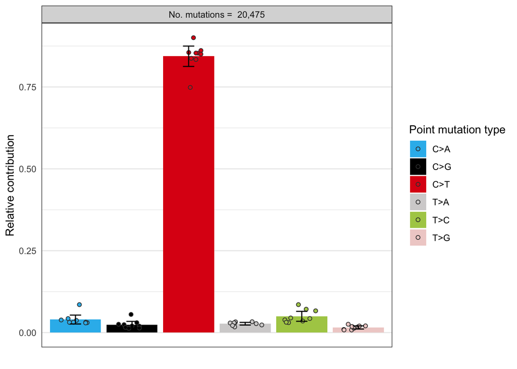

```r
p1 <- plot_spectrum(type_occurrences, indv_points = TRUE)
p1
```

### 96 mutation profile

The 96 mutation profile refers to a classification system that characterizes mutations based on the nucleotide context surrounding them. It considers all possible trinucleotide combinations (96 in total) and quantifies the frequency of specific mutation types within each context.

First we need to generate a 96 trinucleotide mutation count matrix using the function *mut_matrix*:

```r
mut_mat <- mut_matrix(vcf_list = G_lists, ref_genome = ref_genome)
head(mut_mat)
```

```
##         P10_cSCC P2_cSCC P3_cSCC P4_cSCC P5_cSCC P6_cSCC P7_cSCC P8_cSCC
## A[C>A]A        3       6      16       4       2       6       2      10
## A[C>A]C        2       4       6       2       1       2       6       9
## A[C>A]G        0       3       4       2       0       4       1       5
## A[C>A]T        4       1       3       0       1       1       3       3
## C[C>A]A        9       2      16       5       8       6      10       5
## C[C>A]C        5       8       9       0       3       1      12       5
##         P9_cSCC
## A[C>A]A       4
## A[C>A]C       7
## A[C>A]G       4
## A[C>A]T       4
## C[C>A]A      14
## C[C>A]C       6
```

Once we have this matrix, we can generate the 96 profile plots:

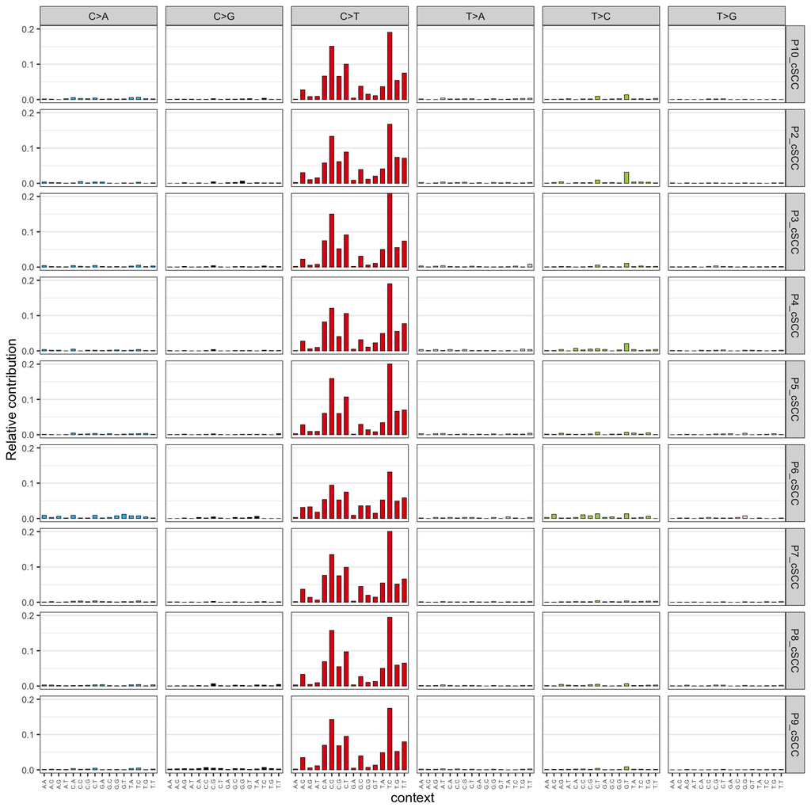

```r
# Plot with 96 profile context
Plot_96 <- plot_96_profile(mut_mat)
Plot_96
```

Interestingly, we can check larger contexts by computing different mutation matrixes:

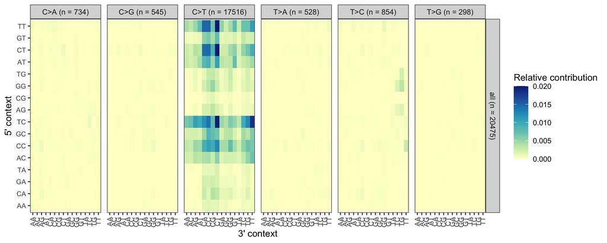

```r
# In this case, we take +-2 nucleotide context
mut_mat_ext_context <- mut_matrix(G_lists, ref_genome, extension = 2)
p2 <- plot_profile_heatmap(mut_mat_ext_context)
p2
```

### Signature refitting

#### Find mathematically optimal contribution of COSMIC signatures (v3)

The process of signature refitting involves measuring the impact of a specific set of signatures on the mutational profile of a sample. This is particularly valuable when analyzing mutational signatures in small groups or individual samples, as well as for comparing one’s own findings with established signatures and published research.

In our case, we will work with the [COSMIC SBS signatures (v3.2)](https://cancer.sanger.ac.uk/signatures/sbs/). we can load them directly from the package. In case you work with non-human species, you can download the mutational signatures from other species (or other human reference genome versions) [here](https://cancer.sanger.ac.uk/signatures/downloads/)

```r
# Getting known signatures
# COSMIC (v3.2) (Alexandrov et al. 2020)
signatures = get_known_signatures()
head(signatures[,1:5])
```

```
##              SBS1         SBS2       SBS3       SBS4        SBS5
## [1,] 0.0008861572 5.800168e-07 0.02080832 0.04219650 0.011997600
## [2,] 0.0022804046 1.480043e-04 0.01650660 0.03329724 0.009438112
## [3,] 0.0001770314 5.230151e-05 0.00175070 0.01559871 0.001849630
## [4,] 0.0012802272 9.780282e-05 0.01220488 0.02949755 0.006608678
## [5,] 0.0003120554 2.080060e-04 0.02250900 0.08069330 0.007428514
## [6,] 0.0017903177 9.530275e-05 0.02531012 0.07969339 0.006138772
```

To avoid problems with the [overfitting](https://en.wikipedia.org/wiki/Overfitting), and because we know that all these samples are coming from skin cancers, we will only interrogate COSMIC mutational signatures already found in these types of cancers ([Alexandrov et al. 2020](https://www.nature.com/articles/s41586-020-1943-3)).

```r
# Filter to prior knowledge in skin cancers
skin_sbs_alexandrov <- c('SBS1','SBS2','SBS5','SBS7a','SBS7b','SBS7c','SBS7d','SBS13','SBS32','SBS40')
signatures <- signatures[,colnames(signatures) %in% skin_sbs_alexandrov]
```

The function *fit_to_signatures_strict* calculates the best possible linear combination of mutational signatures, adhering to non-negative least-squares constraints, in order to reconstruct the mutation matrix with the highest degree of accuracy.

```r
# Run the function
# max_delta parameter: Decreasing this number will make the refitting less strict, while increasing it will make the refitting more strict.
strict_refit <- fit_to_signatures_strict(mut_mat, signatures, max_delta = 0.004)
```

Now, we can get and plot the COSMIC contribution results to our samples (Abosulte contributions)

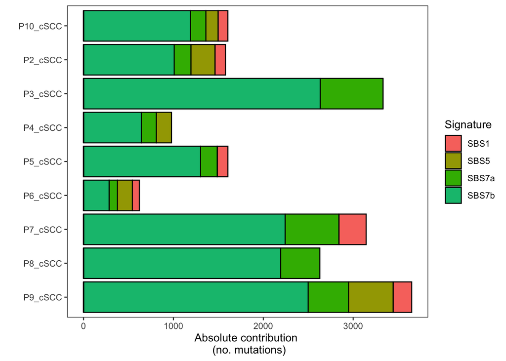

```r
# Getting the contribution of each signature
fit_res_strict <- strict_refit$fit_res

# Absolute contribution
Plot_contribution_abs <- plot_contribution(fit_res_strict$contribution,
                  coord_flip = TRUE,
                  mode = "absolute"
)
Plot_contribution_abs
```

Or relative contribution:

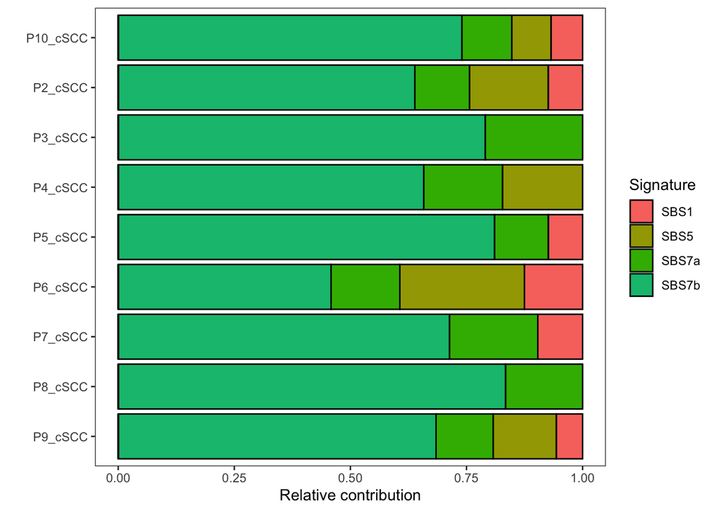

```r
# Relative contribution
Plot_contribution_rel <- plot_contribution(fit_res_strict$contribution,
                                           coord_flip = TRUE,
                                           mode = "relative"
)
Plot_contribution_rel
```

**QUESTION** Could you check in [COSMIC](https://cancer.sanger.ac.uk/signatures/sbs/) the etiology of these SBS signatures? What do you think about these results?

#### Evaluating the performance of the reconstruction

One of the most used methods for quantifying the performance of mutational signature analysis is using the [cosine similarity](https://www.sciencedirect.com/topics/computer-science/cosine-similarity#:~:text=Cosine%20similarity%20measures%20the%20similarity,document%20similarity%20in%20text%20analysis.). This is a measure used to quantify the similarity between two signature vectors. The cosine similarity calculates the cosine of the angle between two signature vectors, which indicates the degree of similarity or alignment between them.

*MutationaPatterns*: *“…We can also plot the cosine similarity between the original and reconstructed matrix for all the samples. When a reconstructed profile has a cosine similarity of more than 0.95 with the original, the reconstructed profile is considered very good…”*

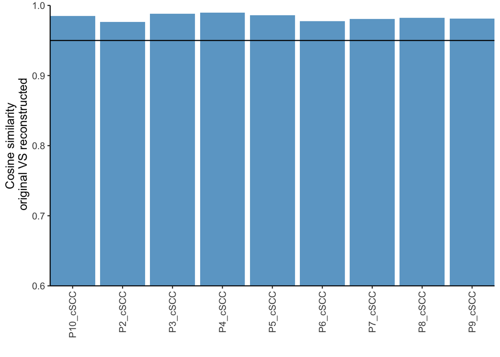

```r
# Check the quality of the reconstruction
Plot_reconstruciton_cos_sim <- plot_original_vs_reconstructed(mut_mat, fit_res_strict$reconstructed,
                               y_intercept = 0.95)
Plot_reconstruciton_cos_sim
```

#### Compute the similarities between groups (sampleIDs) and with indiviual COSMIC signatures

*MutationalPatterns* has some additional functions that are quite interesting:

1. Compare all groups (sampleIDs) against all COSMIC signatures individually and all at once:

```r
signatures_raw = get_known_signatures()
# All groups against all signatures
cos_sim_samples_signatures1 <- cos_sim_matrix(mut_mat, signatures_raw)
head(cos_sim_samples_signatures1[,1:10])
```

```
##               SBS1      SBS2      SBS3      SBS4      SBS5      SBS6     SBS7a
## P10_cSCC 0.1789266 0.3391401 0.3637818 0.1661801 0.4723504 0.3049606 0.7763379
## P2_cSCC  0.2034160 0.3652869 0.3733531 0.1596840 0.5037034 0.3400781 0.7795326
## P3_cSCC  0.1327306 0.3722890 0.3482441 0.1565120 0.4544633 0.2469984 0.8259360
## P4_cSCC  0.1371624 0.3919017 0.3721111 0.1614380 0.4909128 0.2728675 0.8228782
## P5_cSCC  0.1746807 0.3208214 0.3512842 0.1528182 0.4617994 0.2819219 0.7762396
## P6_cSCC  0.3284858 0.4261647 0.4245721 0.2181594 0.5606152 0.4533954 0.7903128
##              SBS7b     SBS7c     SBS7d
## P10_cSCC 0.9721858 0.1068928 0.1350026
## P2_cSCC  0.9552380 0.1047352 0.2035472
## P3_cSCC  0.9712340 0.1156668 0.1217538
## P4_cSCC  0.9713846 0.1095473 0.1712707
## P5_cSCC  0.9742086 0.1032308 0.1068105
## P6_cSCC  0.9122850 0.1192476 0.1639296
```

2. Compare all groups (sampleIDs) between them. It helps to understand if different samples have similar mutational processes ongoing:

```r
# Comparison of samples between them
cos_sim_samples_signatures2 <- cos_sim_matrix(mut_mat, mut_mat)
cos_sim_samples_signatures2
```

```
##           P10_cSCC   P2_cSCC   P3_cSCC   P4_cSCC   P5_cSCC   P6_cSCC   P7_cSCC
## P10_cSCC 1.0000000 0.9901060 0.9928650 0.9863634 0.9964841 0.9639045 0.9927410
## P2_cSCC  0.9901060 1.0000000 0.9814704 0.9829281 0.9869052 0.9697877 0.9830278
## P3_cSCC  0.9928650 0.9814704 1.0000000 0.9891175 0.9921475 0.9523048 0.9896551
## P4_cSCC  0.9863634 0.9829281 0.9891175 1.0000000 0.9828901 0.9627826 0.9859329
## P5_cSCC  0.9964841 0.9869052 0.9921475 0.9828901 1.0000000 0.9562449 0.9878828
## P6_cSCC  0.9639045 0.9697877 0.9523048 0.9627826 0.9562449 1.0000000 0.9708639
## P7_cSCC  0.9927410 0.9830278 0.9896551 0.9859329 0.9878828 0.9708639 1.0000000
## P8_cSCC  0.9948969 0.9862465 0.9951859 0.9866428 0.9959123 0.9583534 0.9907145
## P9_cSCC  0.9955033 0.9889706 0.9886123 0.9854189 0.9898416 0.9657786 0.9926438
##            P8_cSCC   P9_cSCC
## P10_cSCC 0.9948969 0.9955033
## P2_cSCC  0.9862465 0.9889706
## P3_cSCC  0.9951859 0.9886123
## P4_cSCC  0.9866428 0.9854189
## P5_cSCC  0.9959123 0.9898416
## P6_cSCC  0.9583534 0.9657786
## P7_cSCC  0.9907145 0.9926438
## P8_cSCC  1.0000000 0.9928866
## P9_cSCC  0.9928866 1.0000000
```